# FInal_Results

```python
import numpy as np
import pandas as pd
import os
import json
import matplotlib as mpl
import matplotlib.pyplot as plt
import seaborn as sns

from wordcloud import WordCloud, STOPWORDS,ImageColorGenerator
```

I wanted to check what is my current working directory so I can properly import my dataset

```python
os.getcwd()
```

```
'C:\\Users\\Marco\\Documents\\CIND 820'
```

Since I wanted to predict review scores I've selected the reviews dataset primarily to work with review text data.

```python
reviews = []
with open('yelp_academic_dataset_review.json',encoding='utf-8') as fl:
    for i, line in enumerate(fl):
        reviews.append(json.loads(line))
        if i+1 >= 5000:
            break
review = pd.DataFrame(reviews)
review.head()
```

|  | review_id | user_id | business_id | stars | useful | funny | cool | text | date |
| --- | --- | --- | --- | --- | --- | --- | --- | --- | --- |
| 0 | xQY8N_XvtGbearJ5X4QryQ | OwjRMXRC0KyPrIlcjaXeFQ | -MhfebM0QIsKt87iDN-FNw | 2.0 | 5 | 0 | 0 | As someone who has worked with many museums, I... | 2015-04-15 05:21:16 |
| 1 | UmFMZ8PyXZTY2QcwzsfQYA | nIJD_7ZXHq-FX8byPMOkMQ | lbrU8StCq3yDfr-QMnGrmQ | 1.0 | 1 | 1 | 0 | I am actually horrified this place is still in... | 2013-12-07 03:16:52 |
| 2 | LG2ZaYiOgpr2DK_90pYjNw | V34qejxNsCbcgD8C0HVk-Q | HQl28KMwrEKHqhFrrDqVNQ | 5.0 | 1 | 0 | 0 | I love Deagan's. I do. I really do. The atmosp... | 2015-12-05 03:18:11 |
| 3 | i6g_oA9Yf9Y31qt0wibXpw | ofKDkJKXSKZXu5xJNGiiBQ | 5JxlZaqCnk1MnbgRirs40Q | 1.0 | 0 | 0 | 0 | Dismal, lukewarm, defrosted-tasting "TexMex" g... | 2011-05-27 05:30:52 |
| 4 | 6TdNDKywdbjoTkizeMce8A | UgMW8bLE0QMJDCkQ1Ax5Mg | IS4cv902ykd8wj1TR0N3-A | 4.0 | 0 | 0 | 0 | Oh happy day, finally have a Canes near my cas... | 2017-01-14 21:56:57 |

```python
review.to_csv("Yelp_Review.csv")
```

[figure not shown]

```python
review=review[['stars','text']]
#we want to omit the other columns other that text and stars since we want to predict sentiment with text data
review.head()
```

|  | stars | text |
| --- | --- | --- |
| 0 | 2.0 | As someone who has worked with many museums, I... |
| 1 | 1.0 | I am actually horrified this place is still in... |
| 2 | 5.0 | I love Deagan's. I do. I really do. The atmosp... |
| 3 | 1.0 | Dismal, lukewarm, defrosted-tasting "TexMex" g... |
| 4 | 4.0 | Oh happy day, finally have a Canes near my cas... |

```python
review.isnull().sum(axis=0) #checking for null values or missing values in the dataset
```

```
stars    0
text     0
dtype: int64
```

```python
review.info()
```

```
<class 'pandas.core.frame.DataFrame'>
RangeIndex: 5000 entries, 0 to 4999
Data columns (total 2 columns):
 #   Column  Non-Null Count  Dtype
---  ------  --------------  -----
 0   stars   5000 non-null   float64
 1   text    5000 non-null   object
dtypes: float64(1), object(1)
memory usage: 78.2+ KB
```

```python
print(review.describe()) #it is interesting that the test data has a mean that is more towards a neutral to positive review than neutral negaitve
```

```
             stars
count  5000.000000
mean      3.744000
std       1.438638
min       1.000000
25%       3.000000
50%       4.000000
75%       5.000000
max       5.000000
```

```python
review.dtypes
```

```
stars    float64
text      object
dtype: object
```

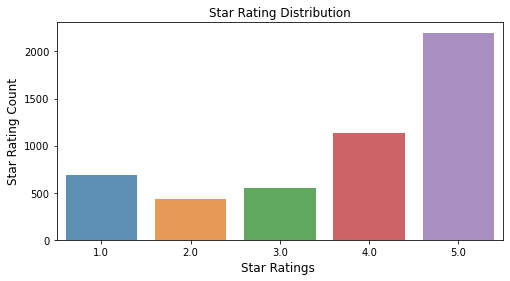

```python
x=review['stars'].value_counts()
x=x.sort_index()
#plot
plt.figure(figsize=(8,4))
ax= sns.barplot(x.index, x.values, alpha=0.8)
plt.title("Star Rating Distribution")
plt.ylabel('Star Rating Count', fontsize=12)
plt.xlabel('Star Ratings ', fontsize=12)
#here is the distribution of star ratings
```

I wanted to visualize the Seperate reviews so I decided to use wordcloud and per star review

```python
stopwords = set(STOPWORDS) #wordcloud function to generate a wordcloud
def wordcloudFunc(data,title = None):
    wordclouds = WordCloud(
        background_color='white',
        stopwords=stopwords,
        max_words=2000,
        max_font_size=40,
        scale=3,
        random_state=0
    ).generate(str(data))

    fig = plt.figure(1,figsize=(20,20))
    plt.axis('off')
    if title:
        fig.subtitle(title, fontsize=20)
        fig.subplots_adjust(top=2.3)

    plt.imshow(wordclouds)
    plt.show()
```

```python
onestarfilt=review['stars']==1.0
onestar=review[onestarfilt]
onestar.head()
#the stars are seperated so I can use the wordcloud function that was created and it can be applied
```

|  | stars | text |
| --- | --- | --- |
| 1 | 1.0 | I am actually horrified this place is still in... |
| 3 | 1.0 | Dismal, lukewarm, defrosted-tasting "TexMex" g... |
| 15 | 1.0 | If I could give less than one star, that would... |
| 16 | 1.0 | 10pm on a super bowl Sunday and they're alread... |
| 18 | 1.0 | Tried to have my car repaired. Even made an a... |

This is the onestar wordcloud function

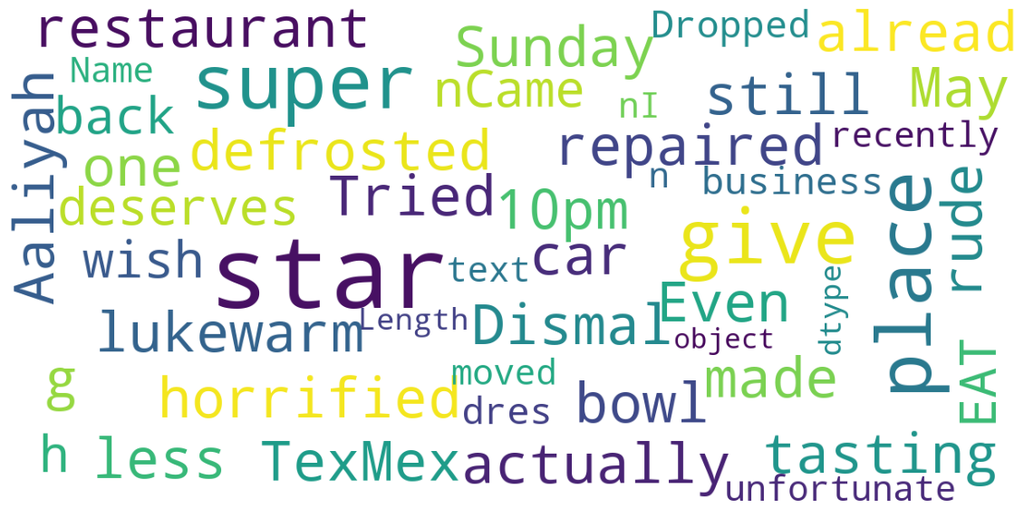

```python
wordcloudFunc(onestar['text'].dropna())
```

```python
twostarfilt=review['stars']==2.0
twostar=review[twostarfilt]
twostar.head()
```

|  | stars | text |
| --- | --- | --- |
| 0 | 2.0 | As someone who has worked with many museums, I... |
| 32 | 2.0 | This actually used to be one of my favorite ho... |
| 63 | 2.0 | Decent food. Fishermen lobster or even congee ... |
| 78 | 2.0 | Pros: Fun atmosphere, great for people watchin... |
| 86 | 2.0 | I love bookstores, and I love to spend some ti... |

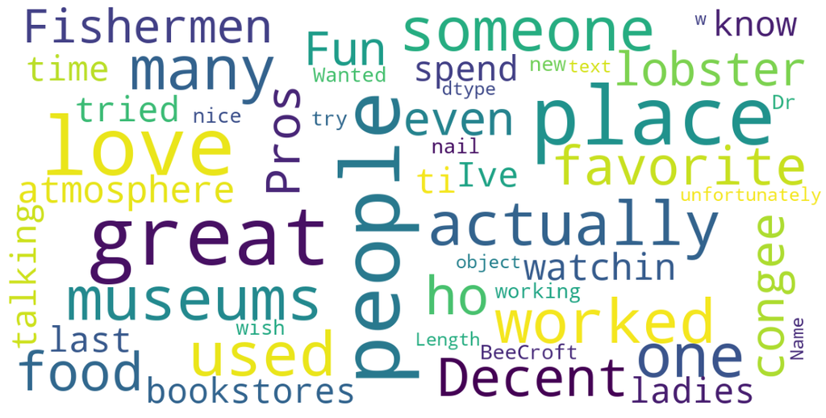

```python
wordcloudFunc(twostar['text'].dropna())
```

```python
threestarfilt=review['stars']==3.0
threestar=review[threestarfilt]
threestar.head()
```

|  | stars | text |
| --- | --- | --- |
| 19 | 3.0 | My husband and I go there once a week since la... |
| 34 | 3.0 | The service is attentive. The decor attractive... |
| 41 | 3.0 | I stayed here back in April. Friday-Sunday. It... |
| 42 | 3.0 | Had brunch here Sunday with a friend. The meal... |
| 44 | 3.0 | Was super excited to bring my boyfriend to thi... |

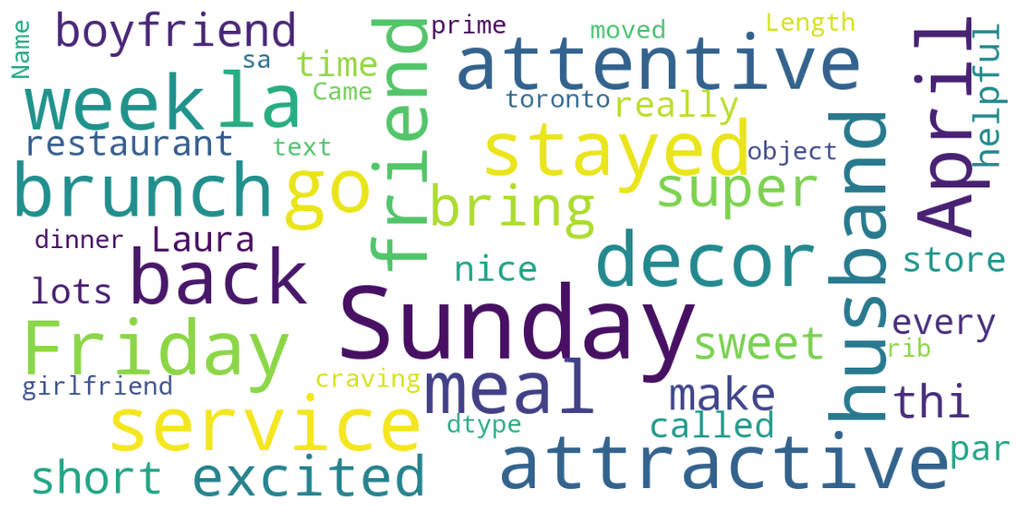

```python
wordcloudFunc(threestar['text'].dropna())
```

```python
fourstarfilt=review['stars']==4.0
fourstar=review[fourstarfilt]
fourstar.head()
```

|  | stars | text |
| --- | --- | --- |
| 4 | 4.0 | Oh happy day, finally have a Canes near my cas... |
| 9 | 4.0 | I have been here twice. Very nice and laid bac... |
| 11 | 4.0 | ORDER In (Delivery) Review\n\nI discovered thi... |
| 17 | 4.0 | A close friend was in town and so instead of t... |
| 22 | 4.0 | Coconut's Fish Cafe is a fantastic, Five Stars... |

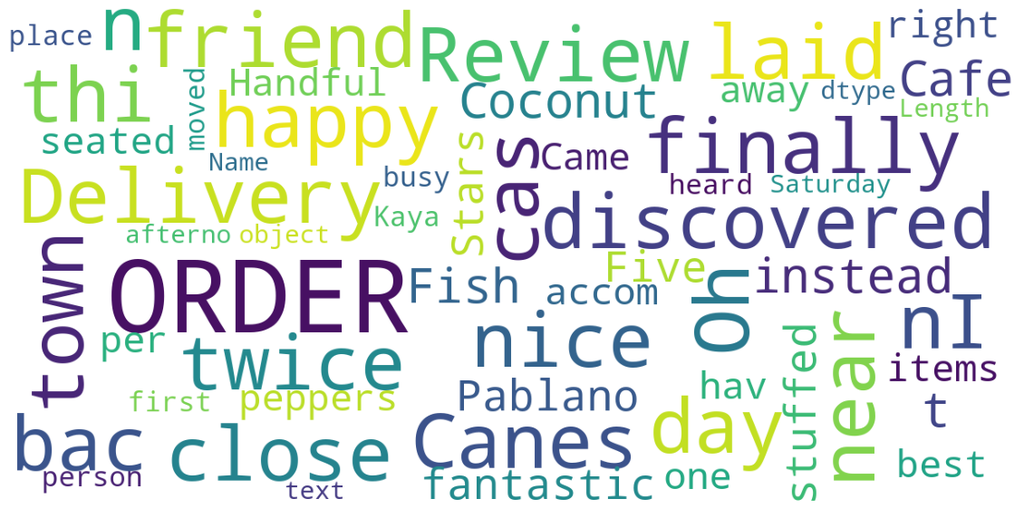

```python
wordcloudFunc(fourstar['text'].dropna())
```

```python
fivestarfilt=review['stars']==5.0
fivestar=review[fivestarfilt]
fivestar.head()
```

|  | stars | text |
| --- | --- | --- |
| 2 | 5.0 | I love Deagan's. I do. I really do. The atmosp... |
| 5 | 5.0 | This is definitely my favorite fast food sub s... |
| 6 | 5.0 | Really good place with simple decor, amazing f... |
| 7 | 5.0 | Awesome office and staff, very professional an... |
| 8 | 5.0 | Most delicious authentic Italian I've had in t... |

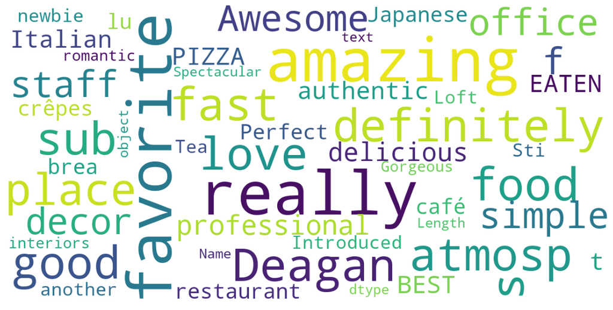

```python
wordcloudFunc(fivestar['text'].dropna())
```

looking at all of the distribution below I can see that they are all relatively distributed the same way with the exception to firve star reviews having a few more shorter reviews than the rest

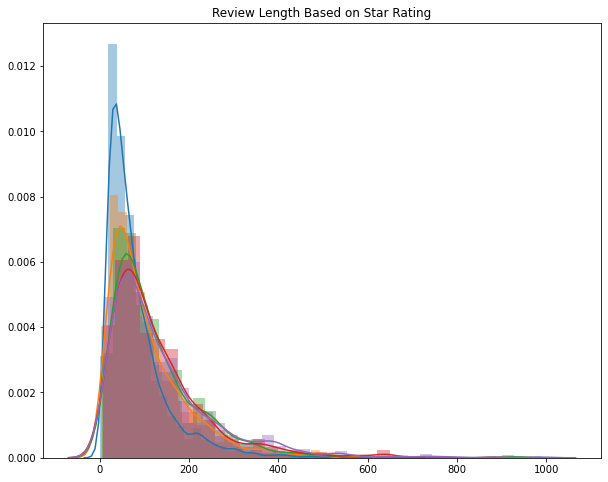

```python
plt.figure(figsize=(10,8))
sns.distplot([len(txt.split()) for txt in fivestar['text'].values])
sns.distplot([len(txt.split()) for txt in fourstar['text'].values])
sns.distplot([len(txt.split()) for txt in threestar['text'].values])
sns.distplot([len(txt.split()) for txt in twostar['text'].values])
sns.distplot([len(txt.split()) for txt in onestar['text'].values])
plt.title("Review Length Based on Star Rating")
plt.show()
```

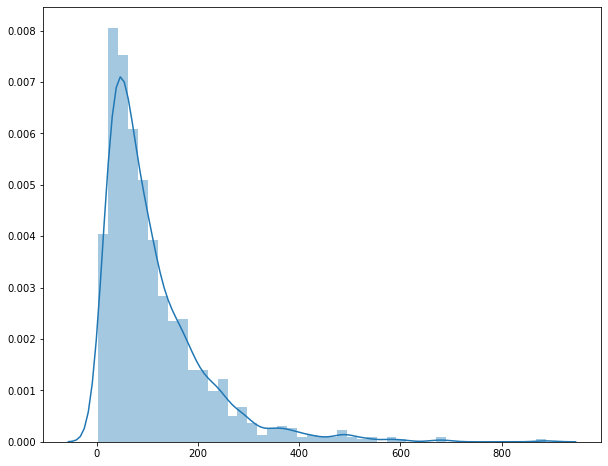

```python
plt.figure(figsize=(10,8))
sns.distplot([len(txt.split()) for txt in fourstar['text'].values])
plt.show()
```

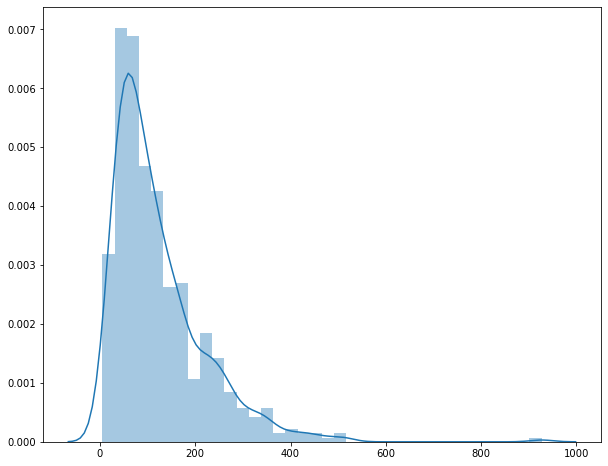

```python
plt.figure(figsize=(10,8))
sns.distplot([len(txt.split()) for txt in threestar['text'].values])
plt.show()
```

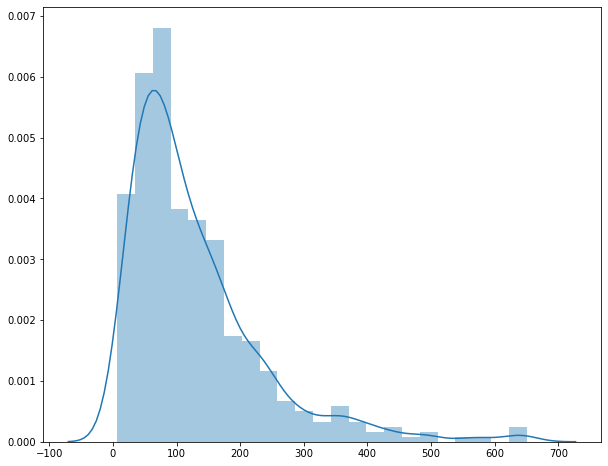

```python
plt.figure(figsize=(10,8))
sns.distplot([len(txt.split()) for txt in twostar['text'].values])
plt.show()
```

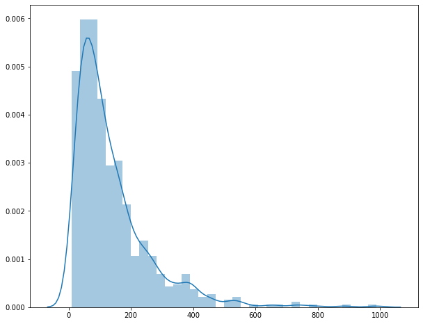

```python
plt.figure(figsize=(10,8))
sns.distplot([len(txt.split()) for txt in onestar['text'].values])
plt.show()
```

```python
review.head()
```

|  | stars | text |
| --- | --- | --- |
| 0 | 2.0 | As someone who has worked with many museums, I... |
| 1 | 1.0 | I am actually horrified this place is still in... |
| 2 | 5.0 | I love Deagan's. I do. I really do. The atmosp... |
| 3 | 1.0 | Dismal, lukewarm, defrosted-tasting "TexMex" g... |
| 4 | 4.0 | Oh happy day, finally have a Canes near my cas... |

```python
"""
I first decided to classify the review star rating by differetiating between positive and negative reviews
"""
review['P/N_tag'] = np.where(review['stars'] > 3.0,1,0)
```

```python
"""
changed the text data to lowercase
"""
review['lowercase'] = review['text'].apply(lambda x: " ".join(word.lower() for word in x.split()))
```

```python
review.head()
```

|  | stars | text | P/N_tag | lowercase |
| --- | --- | --- | --- | --- |
| 0 | 2.0 | As someone who has worked with many museums, I... | 0 | as someone who has worked with many museums, i... |
| 1 | 1.0 | I am actually horrified this place is still in... | 0 | i am actually horrified this place is still in... |
| 2 | 5.0 | I love Deagan's. I do. I really do. The atmosp... | 1 | i love deagan's. i do. i really do. the atmosp... |
| 3 | 1.0 | Dismal, lukewarm, defrosted-tasting "TexMex" g... | 0 | dismal, lukewarm, defrosted-tasting "texmex" g... |
| 4 | 4.0 | Oh happy day, finally have a Canes near my cas... | 1 | oh happy day, finally have a canes near my cas... |

```python
"""added a word count to possibly later use for further iterations to tune the classification algorithms"""

review['WordCount'] = review['text'].apply(lambda x: len(x.split()))
```

```python
"""
this will remove punctuation so that we can further increase accuracy
"""
review['punctuation'] = review['lowercase'].str.replace('[^\w\s]', '')
```

```python
import nltk
from nltk.corpus import stopwords
```

```python
nltk.download('stopwords')
```

```
True
```

```python
"""
this displays the stopword listing
"""
stop_word = stopwords.words("english")
print(stop_word)
```

```
['i', 'me', 'my', 'myself', 'we', 'our', 'ours', 'ourselves', 'you', "you're", "you've", "you'll", "you'd", 'your', 'yours', 'yourself', 'yourselves', 'he', 'him', 'his', 'himself', 'she', "she's", 'her', 'hers', 'herself', 'it', "it's", 'its', 'itself', 'they', 'them', 'their', 'theirs', 'themselve…
```

```python
review.head()
```

|  | stars | text | P/N_tag | lowercase | WordCount | punctuation |
| --- | --- | --- | --- | --- | --- | --- |
| 0 | 2.0 | As someone who has worked with many museums, I... | 0 | as someone who has worked with many museums, i... | 253 | as someone who has worked with many museums i ... |
| 1 | 1.0 | I am actually horrified this place is still in... | 0 | i am actually horrified this place is still in... | 276 | i am actually horrified this place is still in... |
| 2 | 5.0 | I love Deagan's. I do. I really do. The atmosp... | 1 | i love deagan's. i do. i really do. the atmosp... | 83 | i love deagans i do i really do the atmosphere... |
| 3 | 1.0 | Dismal, lukewarm, defrosted-tasting "TexMex" g... | 0 | dismal, lukewarm, defrosted-tasting "texmex" g... | 61 | dismal lukewarm defrostedtasting texmex glop m... |
| 4 | 4.0 | Oh happy day, finally have a Canes near my cas... | 1 | oh happy day, finally have a canes near my cas... | 171 | oh happy day finally have a canes near my casa... |

```python
"""
lastly in the first attempt I removed stop words from the text data
"""
review['CleanText'] = review['punctuation'].apply(lambda x: " ".join(word for word in x.split() if word not in stop_word))
```

```python
review.head()
```

|  | stars | text | P/N_tag | lowercase | WordCount | punctuation | CleanText |
| --- | --- | --- | --- | --- | --- | --- | --- |
| 0 | 2.0 | As someone who has worked with many museums, I... | 0 | as someone who has worked with many museums, i... | 253 | as someone who has worked with many museums i ... | someone worked many museums eager visit galler... |
| 1 | 1.0 | I am actually horrified this place is still in... | 0 | i am actually horrified this place is still in... | 276 | i am actually horrified this place is still in... | actually horrified place still business 3 year... |
| 2 | 5.0 | I love Deagan's. I do. I really do. The atmosp... | 1 | i love deagan's. i do. i really do. the atmosp... | 83 | i love deagans i do i really do the atmosphere... | love deagans really atmosphere cozy festive sh... |
| 3 | 1.0 | Dismal, lukewarm, defrosted-tasting "TexMex" g... | 0 | dismal, lukewarm, defrosted-tasting "texmex" g... | 61 | dismal lukewarm defrostedtasting texmex glop m... | dismal lukewarm defrostedtasting texmex glop m... |
| 4 | 4.0 | Oh happy day, finally have a Canes near my cas... | 1 | oh happy day, finally have a canes near my cas... | 171 | oh happy day finally have a canes near my casa... | oh happy day finally canes near casa yes other... |

```python
review = review.drop(columns=['text','lowercase','punctuation','WordCount'])
review.head()
```

|  | stars | P/N_tag | CleanText |
| --- | --- | --- | --- |
| 0 | 2.0 | 0 | someone worked many museums eager visit galler... |
| 1 | 1.0 | 0 | actually horrified place still business 3 year... |
| 2 | 5.0 | 1 | love deagans really atmosphere cozy festive sh... |
| 3 | 1.0 | 0 | dismal lukewarm defrostedtasting texmex glop m... |
| 4 | 4.0 | 1 | oh happy day finally canes near casa yes other... |

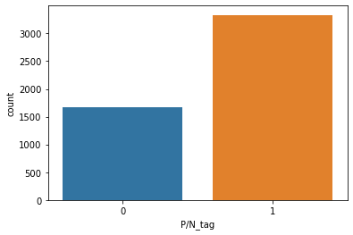

```python
"""Here is a quick Visualisation to displat the difference in unblanced labels"""

sns.countplot(review['P/N_tag'])
```

# TF-IDF

### this will give more weight to words that are unique to a document than to words that are frequent

```python
from sklearn.feature_extraction.text import TfidfVectorizer

def dum_fun(doc):
    return doc
#dum_fun function is just a simple iterator that goes through the documents like a simple iterator.
#Its used as an alternative to the labmbda function

tfidf = TfidfVectorizer(
    analyzer='word',
    ngram_range= (1,1),
    tokenizer= dum_fun,
    preprocessor=dum_fun,
    token_pattern=None
)
```

```python
dependant = tfidf.fit_transform(review['CleanText'])
dependant = dependant.toarray()
```

```python
from sklearn.model_selection import train_test_split
```

```python
"""
we split the dependant variable with a 75%/25% split, the default split.
"""
x_train, x_test,y_train, y_test = train_test_split(dependant, review['P/N_tag'], random_state=50)
```

```python
print(x_train)
```

```
[[0.4943821  0.         0.         ... 0.         0.         0.        ]
 [0.57809505 0.00706507 0.02118712 ... 0.         0.         0.        ]
 [0.57822481 0.         0.01834906 ... 0.         0.         0.        ]
 ...
 [0.6039948  0.         0.         ... 0.         0.         0.        ]
 [0.59334953 0.         0.         ... 0.         0.         0.        ]
 [0.47346729 0.         0.         ... 0.         0.         0.        ]]
```

```python
print(y_train)
```

```
3512    1
115     1
1866    1
636     1
477     1
       ..
3330    0
70      0
132     1
2014    0
1931    1
Name: P/N_tag, Length: 3750, dtype: int32
```

```python
print(dependant.shape)
```

```
(5000, 73)
```

```python
print(x_train.shape)
print(x_test.shape)
print(y_train.shape)
print(y_test.shape)
```

```
(3750, 73)
(1250, 73)
(3750,)
(1250,)
```

# Classification Algorithms

```python
from sklearn.ensemble import RandomForestClassifier
from sklearn.naive_bayes import GaussianNB
from sklearn.naive_bayes import MultinomialNB
from sklearn import svm
from sklearn import naive_bayes
from sklearn.svm import SVC
from sklearn import metrics
from sklearn.metrics import accuracy_score
from sklearn.metrics import classification_report, confusion_matrix
```

### 1. Naive Bayes

```python
%%time
Naive = naive_bayes.MultinomialNB()
Naive.fit(x_train, y_train)

predictions_NB1= Naive.predict(x_test)

print("Naive Bayes Accuracy Score -> ",accuracy_score(predictions_NB1, y_test)*100)
```

```
Naive Bayes Accuracy Score ->  64.72
Wall time: 2.99 ms
```

```python
print(metrics.classification_report(y_test,predictions_NB1))
print(confusion_matrix(y_test,predictions_NB1))
```

```
              precision    recall  f1-score   support

           0       0.00      0.00      0.00       441
           1       0.65      1.00      0.79       809

    accuracy                           0.65      1250
   macro avg       0.32      0.50      0.39      1250
weighted avg       0.42      0.65      0.51      1250

[[  0 441]
 [  0 809]]
```

```python
%%time
NBG = GaussianNB()
NBG.fit(x_train,y_train)

NB_pred1=NBG.predict(x_test)
NB_accuracy=round(metrics.accuracy_score(y_test,NB_pred1)*100,2)
NB_accuracy
```

```
Wall time: 6.98 ms
```

```
35.6
```

```python
print(metrics.classification_report(y_test,NB_pred1))
print(confusion_matrix(y_test,NB_pred1))
```

```
              precision    recall  f1-score   support

           0       0.35      1.00      0.52       441
           1       1.00      0.00      0.01       809

    accuracy                           0.36      1250
   macro avg       0.68      0.50      0.27      1250
weighted avg       0.77      0.36      0.19      1250

[[441   0]
 [805   4]]
```

### 2. Random Forest

```python
%%time
text_classifier = RandomForestClassifier(n_estimators=200, random_state=0)
text_classifier.fit(x_train,y_train)


predictions_TC1= text_classifier.predict(x_test)

print("Random Forest Accuracy Score -> ",accuracy_score(predictions_TC1, y_test)*100)
```

```
Random Forest Accuracy Score ->  69.19999999999999
Wall time: 1.53 s
```

```python
print(metrics.classification_report(y_test,predictions_TC1))
print(confusion_matrix(y_test,predictions_TC1))
```

```
              precision    recall  f1-score   support

           0       0.66      0.26      0.37       441
           1       0.70      0.93      0.80       809

    accuracy                           0.69      1250
   macro avg       0.68      0.59      0.58      1250
weighted avg       0.69      0.69      0.65      1250

[[113 328]
 [ 57 752]]
```

### 3. Support Vector Classifier

```python
%%time
clf=svm.SVC(decision_function_shape='ovo')
clf.fit(x_train, y_train)

predictions_CLF1= clf.predict(x_test)

print("SVC Accuracy Score -> ",accuracy_score(predictions_CLF1, y_test)*100)
```

```
SVC Accuracy Score ->  65.12
Wall time: 898 ms
```

```python
print(metrics.classification_report(y_test,predictions_CLF1))
print(confusion_matrix(y_test,predictions_CLF1))
```

```
              precision    recall  f1-score   support

           0       0.73      0.02      0.04       441
           1       0.65      1.00      0.79       809

    accuracy                           0.65      1250
   macro avg       0.69      0.51      0.41      1250
weighted avg       0.68      0.65      0.52      1250

[[  8 433]
 [  3 806]]
```

# 2nd Attempt

```python
review.head()
```

|  | stars | P/N_tag | CleanText |
| --- | --- | --- | --- |
| 0 | 2.0 | 0 | someone worked many museums eager visit galler... |
| 1 | 1.0 | 0 | actually horrified place still business 3 year... |
| 2 | 5.0 | 1 | love deagans really atmosphere cozy festive sh... |
| 3 | 1.0 | 0 | dismal lukewarm defrostedtasting texmex glop m... |
| 4 | 4.0 | 1 | oh happy day finally canes near casa yes other... |

```python
def getsentiment(x):
    if x > 3.0:
        return 2
    elif x == 3.0:
        return 1
    elif x <= 2:
        return 0
```

```python
review['tags'] =  review['stars'].apply(lambda x: getsentiment(x))
```

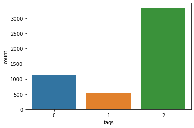

```python
"""Here is a quick Visualisation to display the difference in unblanced labels with three levels"""
sns.countplot(review['tags'])
```

```python
review['TokenizedText'] = review['CleanText'].apply(lambda x: nltk.word_tokenize(x))
```

```python
review.head()
```

|  | stars | P/N_tag | CleanText | tags | TokenizedText |
| --- | --- | --- | --- | --- | --- |
| 0 | 2.0 | 0 | someone worked many museums eager visit galler... | 0 | [someone, worked, many, museums, eager, visit,... |
| 1 | 1.0 | 0 | actually horrified place still business 3 year... | 0 | [actually, horrified, place, still, business, ... |
| 2 | 5.0 | 1 | love deagans really atmosphere cozy festive sh... | 2 | [love, deagans, really, atmosphere, cozy, fest... |
| 3 | 1.0 | 0 | dismal lukewarm defrostedtasting texmex glop m... | 0 | [dismal, lukewarm, defrostedtasting, texmex, g... |
| 4 | 4.0 | 1 | oh happy day finally canes near casa yes other... | 2 | [oh, happy, day, finally, canes, near, casa, y... |

```python
"""
creating an object to lemmatize the data called 'wn'
"""
wn=nltk.WordNetLemmatizer()

def lemmatization(tokens):
    text = [wn.lemmatize(word) for word in tokens if word not in stop_word]
    return text
```

```python
review['Lemmatized_Text']= review['TokenizedText'].apply(lambda x : lemmatization(x))
review.head()
```

|  | stars | P/N_tag | CleanText | tags | TokenizedText | Lemmatized_Text |
| --- | --- | --- | --- | --- | --- | --- |
| 0 | 2.0 | 0 | someone worked many museums eager visit galler... | 0 | [someone, worked, many, museums, eager, visit,... | [someone, worked, many, museum, eager, visit, ... |
| 1 | 1.0 | 0 | actually horrified place still business 3 year... | 0 | [actually, horrified, place, still, business, ... | [actually, horrified, place, still, business, ... |
| 2 | 5.0 | 1 | love deagans really atmosphere cozy festive sh... | 2 | [love, deagans, really, atmosphere, cozy, fest... | [love, deagans, really, atmosphere, cozy, fest... |
| 3 | 1.0 | 0 | dismal lukewarm defrostedtasting texmex glop m... | 0 | [dismal, lukewarm, defrostedtasting, texmex, g... | [dismal, lukewarm, defrostedtasting, texmex, g... |
| 4 | 4.0 | 1 | oh happy day finally canes near casa yes other... | 2 | [oh, happy, day, finally, canes, near, casa, y... | [oh, happy, day, finally, cane, near, casa, ye... |

```python
from nltk.tokenize.treebank import TreebankWordDetokenizer
DT=TreebankWordDetokenizer()
review['Rejoined_Text']= review['TokenizedText'].apply(lambda x : DT.detokenize(x))
review.head()
```

|  | stars | P/N_tag | CleanText | tags | TokenizedText | Lemmatized_Text | Rejoined_Text |
| --- | --- | --- | --- | --- | --- | --- | --- |
| 0 | 2.0 | 0 | someone worked many museums eager visit galler... | 0 | [someone, worked, many, museums, eager, visit,... | [someone, worked, many, museum, eager, visit, ... | someone worked many museums eager visit galler... |
| 1 | 1.0 | 0 | actually horrified place still business 3 year... | 0 | [actually, horrified, place, still, business, ... | [actually, horrified, place, still, business, ... | actually horrified place still business 3 year... |
| 2 | 5.0 | 1 | love deagans really atmosphere cozy festive sh... | 2 | [love, deagans, really, atmosphere, cozy, fest... | [love, deagans, really, atmosphere, cozy, fest... | love deagans really atmosphere cozy festive sh... |
| 3 | 1.0 | 0 | dismal lukewarm defrostedtasting texmex glop m... | 0 | [dismal, lukewarm, defrostedtasting, texmex, g... | [dismal, lukewarm, defrostedtasting, texmex, g... | dismal lukewarm defrostedtasting texmex glop m... |
| 4 | 4.0 | 1 | oh happy day finally canes near casa yes other... | 2 | [oh, happy, day, finally, canes, near, casa, y... | [oh, happy, day, finally, cane, near, casa, ye... | oh happy day finally canes near casa yes other... |

```python
dependant = tfidf.fit_transform(review['Rejoined_Text'])
dependant = dependant.toarray()
```

```python
"""
we split the dependant variable with a 75%/25% split, the default split.
"""
x_train, x_test,y_train, y_test = train_test_split(dependant, review['tags'], random_state=50)
```

```python
print(x_train.shape)
print(x_test.shape)
print(y_train.shape)
print(y_test.shape)
```

```
(3750, 73)
(1250, 73)
(3750,)
(1250,)
```

```python
from imblearn.over_sampling import SMOTE
smote=SMOTE()
#using oversampling to make sure the other tags can catch up to the positive sentiment label
```

```python
x_train_smote, y_train_smote = smote.fit_sample(x_train,y_train)
```

```python
from collections import Counter
print("before smote :", Counter(y_train))
print("after smote :", Counter(y_train_smote))
```

```
before smote : Counter({2: 2521, 0: 825, 1: 404})
after smote : Counter({2: 2521, 0: 2521, 1: 2521})
```

### 1. Support Vector Machine

```python
%%time
clf=svm.SVC(decision_function_shape='ovo')
clf.fit(x_train_smote, y_train_smote)

predictions_CLF2= clf.predict(x_test)

print("SVC Accuracy Score -> ",accuracy_score(predictions_CLF2, y_test)*100)
```

```
SVC Accuracy Score ->  50.4
Wall time: 4.12 s
```

```python
print(metrics.classification_report(y_test,predictions_CLF2))
print(confusion_matrix(y_test,predictions_CLF2))
```

```
              precision    recall  f1-score   support

           0       0.44      0.52      0.47       295
           1       0.16      0.42      0.23       146
           2       0.80      0.51      0.63       809

    accuracy                           0.50      1250
   macro avg       0.47      0.49      0.44      1250
weighted avg       0.64      0.50      0.54      1250

[[153  79  63]
 [ 46  62  38]
 [151 243 415]]
```

### 2. Random Forest

```python
%%time
text_classifier = RandomForestClassifier(n_estimators=500, random_state=0)
text_classifier.fit(x_train_smote,y_train_smote)


predictions_TC2= text_classifier.predict(x_test)

print("Random Forest Accuracy Score -> ",accuracy_score(predictions_TC2, y_test)*100)
```

```
Random Forest Accuracy Score ->  63.44
Wall time: 7.87 s
```

```python
print(metrics.classification_report(y_test,predictions_TC2))
print(confusion_matrix(y_test,predictions_TC2))
```

```
              precision    recall  f1-score   support

           0       0.46      0.37      0.41       295
           1       0.16      0.07      0.10       146
           2       0.71      0.83      0.77       809

    accuracy                           0.63      1250
   macro avg       0.44      0.42      0.42      1250
weighted avg       0.59      0.63      0.60      1250

[[110  15 170]
 [ 33  10 103]
 [ 97  39 673]]
```

### 3. Naive Bayes

```python
%%time
Naive = naive_bayes.MultinomialNB()
Naive.fit(x_train_smote, y_train_smote)

predictions_NB2= Naive.predict(x_test)

print("Naive Bayes Accuracy Score -> ",accuracy_score(predictions_NB2, y_test)*100)
```

```
Naive Bayes Accuracy Score ->  55.04
Wall time: 3.99 ms
```

```python
print(metrics.classification_report(y_test,predictions_NB2))
print(confusion_matrix(y_test,predictions_NB2))
```

```
              precision    recall  f1-score   support

           0       0.42      0.46      0.44       295
           1       0.15      0.26      0.19       146
           2       0.77      0.64      0.70       809

    accuracy                           0.55      1250
   macro avg       0.45      0.45      0.44      1250
weighted avg       0.62      0.55      0.58      1250

[[136  69  90]
 [ 48  38  60]
 [140 155 514]]
```

## 3rd Attempt

```python
rev = []
with open('yelp_academic_dataset_review.json',encoding='utf-8') as fl:
    for i, line in enumerate(fl):
        reviews.append(json.loads(line))
        if i+1 >= 50000:
            break
df_rev = pd.DataFrame(reviews)
df_rev.head()

#I plan on using undersampling to check for the results to see if there are any differences.
#I didnt want fewer samples so undersampling was needed
```

|  | review_id | user_id | business_id | stars | useful | funny | cool | text | date |
| --- | --- | --- | --- | --- | --- | --- | --- | --- | --- |
| 0 | xQY8N_XvtGbearJ5X4QryQ | OwjRMXRC0KyPrIlcjaXeFQ | -MhfebM0QIsKt87iDN-FNw | 2.0 | 5 | 0 | 0 | As someone who has worked with many museums, I... | 2015-04-15 05:21:16 |
| 1 | UmFMZ8PyXZTY2QcwzsfQYA | nIJD_7ZXHq-FX8byPMOkMQ | lbrU8StCq3yDfr-QMnGrmQ | 1.0 | 1 | 1 | 0 | I am actually horrified this place is still in... | 2013-12-07 03:16:52 |
| 2 | LG2ZaYiOgpr2DK_90pYjNw | V34qejxNsCbcgD8C0HVk-Q | HQl28KMwrEKHqhFrrDqVNQ | 5.0 | 1 | 0 | 0 | I love Deagan's. I do. I really do. The atmosp... | 2015-12-05 03:18:11 |
| 3 | i6g_oA9Yf9Y31qt0wibXpw | ofKDkJKXSKZXu5xJNGiiBQ | 5JxlZaqCnk1MnbgRirs40Q | 1.0 | 0 | 0 | 0 | Dismal, lukewarm, defrosted-tasting "TexMex" g... | 2011-05-27 05:30:52 |
| 4 | 6TdNDKywdbjoTkizeMce8A | UgMW8bLE0QMJDCkQ1Ax5Mg | IS4cv902ykd8wj1TR0N3-A | 4.0 | 0 | 0 | 0 | Oh happy day, finally have a Canes near my cas... | 2017-01-14 21:56:57 |

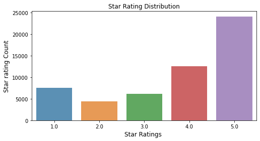

```python
x=df_rev['stars'].value_counts()
x=x.sort_index()
#plot
plt.figure(figsize=(8,4))
ax= sns.barplot(x.index, x.values, alpha=0.8)
plt.title("Star Rating Distribution")
plt.ylabel('Star rating Count', fontsize=12)
plt.xlabel('Star Ratings ', fontsize=12)

#it's nice to see that the distribution is virtually the same if more data is loaded
```

```python
df_rev=df_rev[['stars','text']]
df_rev.head()
```

|  | stars | text |
| --- | --- | --- |
| 0 | 2.0 | As someone who has worked with many museums, I... |
| 1 | 1.0 | I am actually horrified this place is still in... |
| 2 | 5.0 | I love Deagan's. I do. I really do. The atmosp... |
| 3 | 1.0 | Dismal, lukewarm, defrosted-tasting "TexMex" g... |
| 4 | 4.0 | Oh happy day, finally have a Canes near my cas... |

```python
df_rev['lowercase'] = df_rev['text'].apply(lambda x: " ".join(word.lower() for word in x.split()))
df_rev['punctuation'] = df_rev['lowercase'].str.replace('[^\w\s]', '')
df_rev['CleanText'] = df_rev['punctuation'].apply(lambda x: " ".join(word for word in x.split() if word not in stop_word))
df_rev = df_rev.drop(columns=['text','lowercase','punctuation'])
df_rev.head()
```

|  | stars | CleanText |
| --- | --- | --- |
| 0 | 2.0 | someone worked many museums eager visit galler... |
| 1 | 1.0 | actually horrified place still business 3 year... |
| 2 | 5.0 | love deagans really atmosphere cozy festive sh... |
| 3 | 1.0 | dismal lukewarm defrostedtasting texmex glop m... |
| 4 | 4.0 | oh happy day finally canes near casa yes other... |

```python
df_rev['TokenizedText'] = df_rev['CleanText'].apply(lambda x: nltk.word_tokenize(x))
df_rev['Lemmatized_Text']= df_rev['TokenizedText'].apply(lambda x : lemmatization(x))
df_rev['Rejoined_Text']= df_rev['TokenizedText'].apply(lambda x : DT.detokenize(x))
df_rev['tags'] =  df_rev['stars'].apply(lambda x: getsentiment(x))
df_rev.head()
```

|  | stars | CleanText | TokenizedText | Lemmatized_Text | Rejoined_Text | tags |
| --- | --- | --- | --- | --- | --- | --- |
| 0 | 2.0 | someone worked many museums eager visit galler... | [someone, worked, many, museums, eager, visit,... | [someone, worked, many, museum, eager, visit, ... | someone worked many museums eager visit galler... | 0 |
| 1 | 1.0 | actually horrified place still business 3 year... | [actually, horrified, place, still, business, ... | [actually, horrified, place, still, business, ... | actually horrified place still business 3 year... | 0 |
| 2 | 5.0 | love deagans really atmosphere cozy festive sh... | [love, deagans, really, atmosphere, cozy, fest... | [love, deagans, really, atmosphere, cozy, fest... | love deagans really atmosphere cozy festive sh... | 2 |
| 3 | 1.0 | dismal lukewarm defrostedtasting texmex glop m... | [dismal, lukewarm, defrostedtasting, texmex, g... | [dismal, lukewarm, defrostedtasting, texmex, g... | dismal lukewarm defrostedtasting texmex glop m... | 0 |
| 4 | 4.0 | oh happy day finally canes near casa yes other... | [oh, happy, day, finally, canes, near, casa, y... | [oh, happy, day, finally, cane, near, casa, ye... | oh happy day finally canes near casa yes other... | 2 |

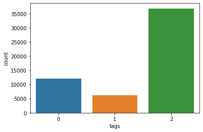

```python
"""Here is a quick Visualisation to display the difference in unblanced labels with three levels"""
sns.countplot(df_rev['tags'])
```

```python
dependant = tfidf.fit_transform(df_rev['Rejoined_Text'])
dependant = dependant.toarray()
```

```python
x_train, x_test,y_train, y_test = train_test_split(dependant, df_rev['tags'], random_state=50)
```

```python
print("before smote :", Counter(y_train))
```

```
before smote : Counter({2: 27526, 0: 9126, 1: 4598})
```

```python
from imblearn.under_sampling import RandomUnderSampler
rus=RandomUnderSampler(sampling_strategy={0:4598,1:4598,2:4598})
x_train_under,y_train_under=rus.fit_resample(x_train,y_train)
```

```python
print("after smote :", Counter(y_train_under))
```

```
after smote : Counter({0: 4598, 1: 4598, 2: 4598})
```

### 1. Random Forest

```python
%%time
text_classifier = RandomForestClassifier(n_estimators=200, random_state=0)
text_classifier.fit(x_train_under,y_train_under)


predictions_TC3= text_classifier.predict(x_test)

print("Random Forest Accuracy Score -> ",accuracy_score(predictions_TC3, y_test)*100)
```

```
Random Forest Accuracy Score ->  56.879999999999995
Wall time: 10.6 s
```

```python
print(metrics.classification_report(y_test,predictions_TC3))
print(confusion_matrix(y_test,predictions_TC3))
```

```
              precision    recall  f1-score   support

           0       0.42      0.57      0.49      2939
           1       0.21      0.43      0.28      1557
           2       0.83      0.59      0.69      9254

    accuracy                           0.57     13750
   macro avg       0.49      0.53      0.49     13750
weighted avg       0.67      0.57      0.60     13750

[[1671  602  666]
 [ 452  666  439]
 [1810 1960 5484]]
```

### 2. Naive Bayes

```python
%%time
Naive = naive_bayes.MultinomialNB()
Naive.fit(x_train_under, y_train_under)

predictions_NB3= Naive.predict(x_test)

print("Naive Bayes Accuracy Score -> ",accuracy_score(predictions_NB3, y_test)*100)
```

```
Naive Bayes Accuracy Score ->  58.14545454545454
Wall time: 60.8 ms
```

```python
print(metrics.classification_report(y_test,predictions_NB3))
print(confusion_matrix(y_test,predictions_NB3))
```

```
              precision    recall  f1-score   support

           0       0.37      0.46      0.41      2939
           1       0.17      0.21      0.19      1557
           2       0.78      0.68      0.73      9254

    accuracy                           0.58     13750
   macro avg       0.44      0.45      0.44     13750
weighted avg       0.62      0.58      0.60     13750

[[1359  510 1070]
 [ 482  332  743]
 [1799 1151 6304]]
```

### 3. Support Vector Classifier

```python
%%time
clf=svm.SVC(decision_function_shape='ovo')
clf.fit(x_train_under, y_train_under)

predictions_CLF3= clf.predict(x_test)

print("SVC Accuracy Score -> ",accuracy_score(predictions_CLF3, y_test)*100)
```

```
SVC Accuracy Score ->  50.99636363636364
Wall time: 3min 16s
```

```python
print(metrics.classification_report(y_test,predictions_CLF3))
print(confusion_matrix(y_test,predictions_CLF3))
```

```
              precision    recall  f1-score   support

           0       0.40      0.54      0.46      2939
           1       0.17      0.47      0.25      1557
           2       0.85      0.51      0.63      9254

    accuracy                           0.51     13750
   macro avg       0.47      0.51      0.45     13750
weighted avg       0.68      0.51      0.55     13750

[[1600  861  478]
 [ 475  732  350]
 [1889 2685 4680]]
```

## Conclusion

In this project, Yelp review ratings are predicted through supervised machine learning models. With various degrees of success